# Using phantasus application

Daria Zenkova

2017-09-18

This is an extended version of the project Morpheus. We are integrating widely used gene epression analysis methods from Bioconductor. You can use it in multiple ways, either locally, using `servePhantasus`-function from this package, this way would be described in this tutorial, either on [web-site](https://artyomovlab.wustl.edu/phantasus).

## Loading required libraries

That package needs GEOquery as a dependency. Although, we recommend to install this package from it’s forked version due to its better cache support:

```r
devtools::install_github('assaron/GEOquery')
```

## Running

To run this package use its exported function:

```r
library(phantasus)
servePhantasus()
```

This command will run the application with default parameters, open it in your default browser (from browser option) with address http://0.0.0.0:8000.

## Loading a dataset for analysis

### Prepare the dataset for analysis

#### Open the datasetg

Choose a loading option “GEO Datasets” and put “GSE53986” in the input field. After a few seconds, corresponding heatmap will be loaded.

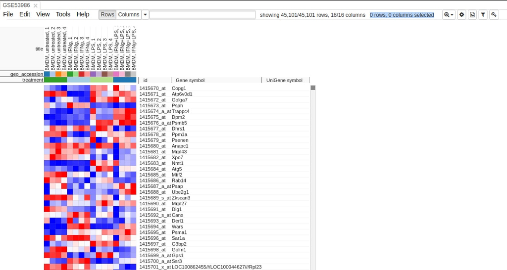

#### Adjust values

As you can see on the image, values are not scaled. So for the proper further analysis it is recommended to rescale the series matrix.

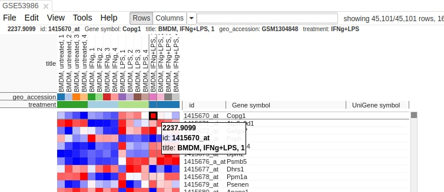

To adjust values go to Tools/Adjust and use Log2 and Quantile Normalization.

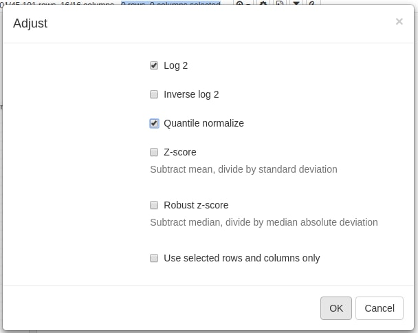

#### Remove duplicates

There can be duplicated genes, it is important to collapse their values.

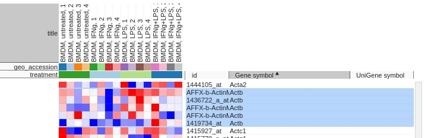

For that go to Tools/Collapse and choose “Mean” as the method and “Gene Symbol” as the collapse field.

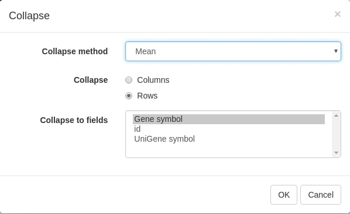

#### Filter lowly expressed genes

To calculate mean expression of each gene go to Tools/Create Calculated Annotation.

Put there annotation name and formula for calculation.

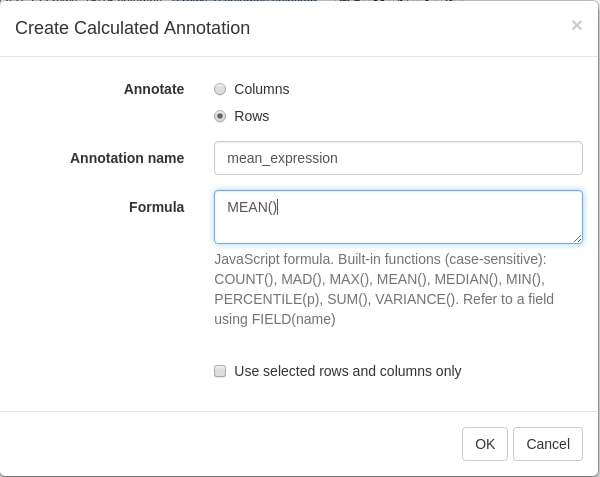

The result should look like this, now you can use this annotation to sort genes by:

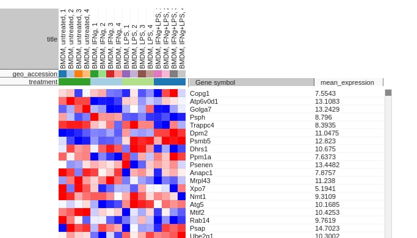

To filter genes go to Tools/Filter, press “Add”, choose “mean_expression” as the field, then press to “Switch to top filter”, and input the number of genes you want to proceed with.

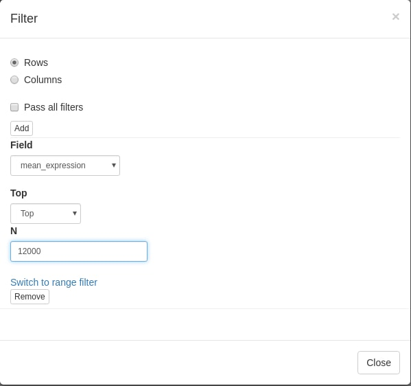

Then you can close tool, the added filter will be still active. Although it is more convenient to extract this genes to a new dataset, so select all genes (click on any gene and press Ctrl+A) and use Tools/New Heat Map (Ctrl+X).

### Explore the dataset

#### PCA Plot

Use Tools/PCA Plot to analyse the data with Principal Component Analysis method.

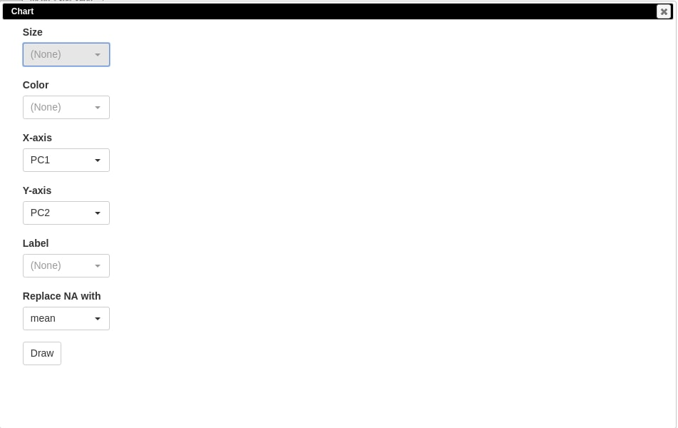

You can customize color, size and label of points on the chart by values in annotation. By analysing the plot you may find some outliers that need to be analysed further to see if they can be eliminated.

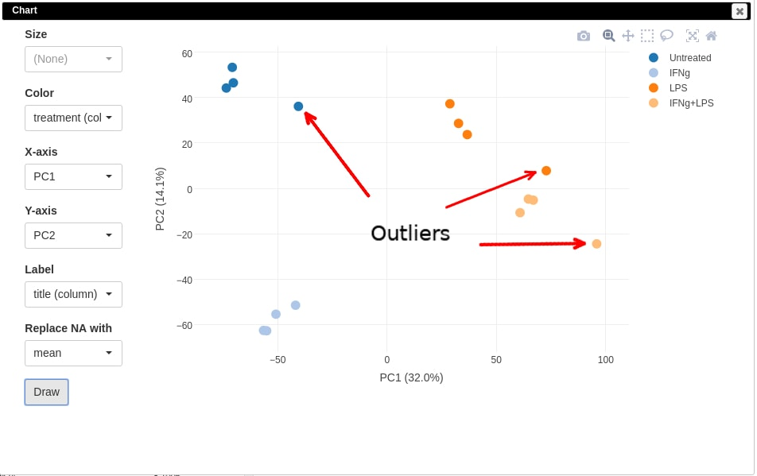

#### K-means clustering

Use Tools/k-means to cluster genes into predefined number of clusters.

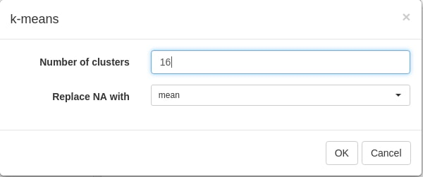

Then you can sort by annotation “clusters” and view the whole dataset by using View/Fit to window. Here you can also see outlier samples.

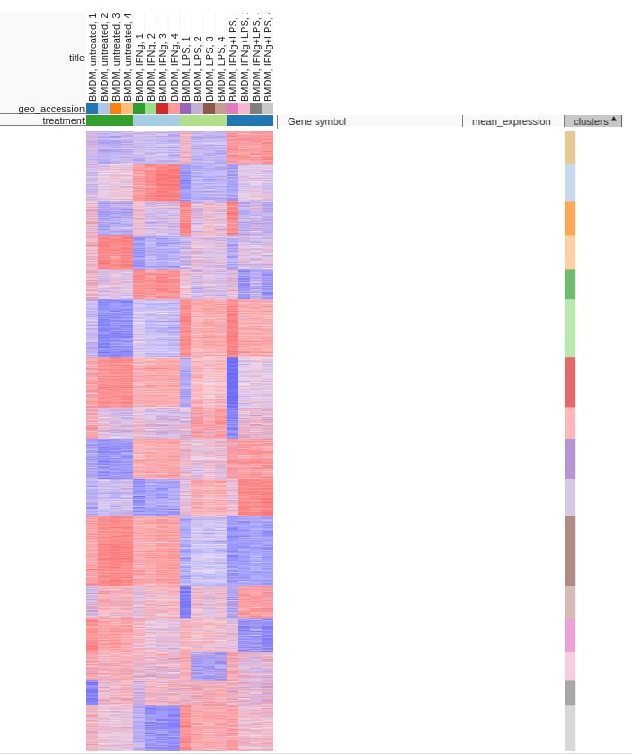

#### Hierarchical clustering

Use Tool/Hierarchical clustering to cluster samples.

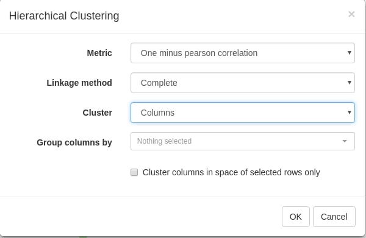

#### Filtering outliers

Now, when outliers are confirmed, you can choose good samples and extract them into another heatmap (Ctrl+X).

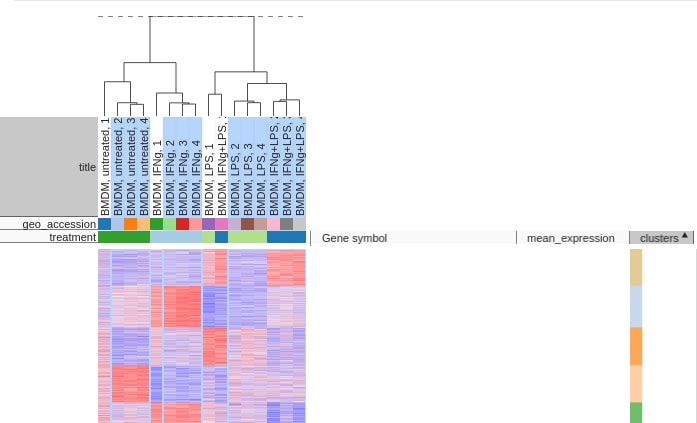

#### Differential expression

Use Tools/Limma to compare samples. Choose “treatment” as a field, “Untreated” and “LPS” as classes.

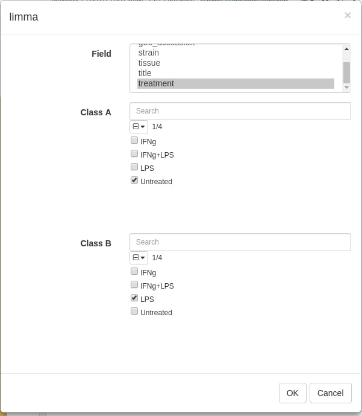

Now you can sort by t-statistic and see genes with the highest difference between classes.

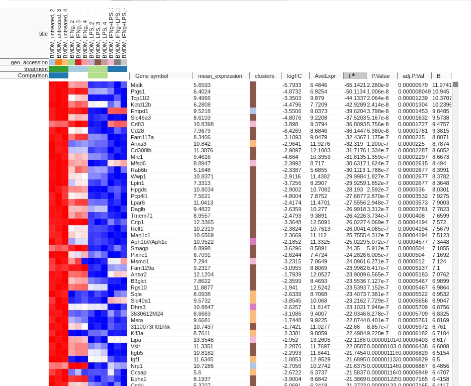

## Feedback

You can see known issues and place yours here: (https://github.com/ctlab/phantasus/issues)